# friedman_data624_wk4

Alice Friedman

2023-06-25

## Week 4: Linear Regression and Its Cousins

### KJ 6.3

**A chemical manufacturing process for a pharmaceutical product was discussed in Sect. 1.4. In this problem, the objective is to understand the relationship between biological measurements of the raw materials (predictors), measurements of the manufacturing process (predictors), and the response of the product yield. Biological predictors cannot be changed but can be used to assess the quality of the raw material before processing. On the other hand, manufacturing process predictors can be changed in the manufacturing process. Improving product yield by 1 % will boost revenue by approximately one hundred thousand dollars per batch.**

#### (a)

**Start R and use these commands to load the data:**

```
> library(AppliedPredictiveModeling)
> data(ChemicalManufacturingProcess)
```

**The matrix processPredictors contains the 57 predictors (12 describing the input biological material and 45 describing the process predictors) for the 176 manufacturing runs. yield contains the percent yield for each run.**

```r
# Load data
library(AppliedPredictiveModeling)
library(psych)
data(ChemicalManufacturingProcess)
head(ChemicalManufacturingProcess, 5)
```

```
##   Yield BiologicalMaterial01 BiologicalMaterial02 BiologicalMaterial03
## 1 38.00                 6.25                49.58                56.97
## 2 42.44                 8.01                60.97                67.48
## 3 42.03                 8.01                60.97                67.48
## 4 41.42                 8.01                60.97                67.48
## 5 42.49                 7.47                63.33                72.25
##   BiologicalMaterial04 BiologicalMaterial05 BiologicalMaterial06
## 1                12.74                19.51                43.73
## 2                14.65                19.36                53.14
## 3                14.65                19.36                53.14
## 4                14.65                19.36                53.14
## 5                14.02                17.91                54.66
##   BiologicalMaterial07 BiologicalMaterial08 BiologicalMaterial09
## 1                  100                16.66                11.44
## 2                  100                19.04                12.55
```

[output cut: 99 more lines]

```r
describe(ChemicalManufacturingProcess)
```

```
##                        vars   n    mean      sd  median trimmed   mad     min
## Yield                     1 176   40.18    1.85   39.97   40.12  1.97   35.25
## BiologicalMaterial01      2 176    6.41    0.71    6.30    6.39  0.67    4.58
## BiologicalMaterial02      3 176   55.69    4.03   55.09   55.58  4.58   46.87
## BiologicalMaterial03      4 176   67.70    4.00   67.22   67.68  4.28   56.97
## BiologicalMaterial04      5 176   12.35    1.77   12.10   12.19  1.37    9.38
## BiologicalMaterial05      6 176   18.60    1.84   18.49   18.55  1.88   13.24
## BiologicalMaterial06      7 176   48.91    3.75   48.46   48.74  3.94   40.60
## BiologicalMaterial07      8 176  100.01    0.11  100.00  100.00  0.00  100.00
## BiologicalMaterial08      9 176   17.49    0.68   17.51   17.47  0.59   15.88
## BiologicalMaterial09     10 176   12.85    0.42   12.84   12.86  0.42   11.44
## BiologicalMaterial10     11 176    2.80    0.60    2.71    2.73  0.40    1.77
## BiologicalMaterial11     12 176  146.95    4.82  146.08  146.79  4.11  135.81
## BiologicalMaterial12     13 176   20.20    0.77   20.12   20.18  0.67   18.35
## ManufacturingProcess01   14 175   11.21    1.82   11.40   11.41  1.04    0.00
## ManufacturingProcess02   15 173   16.68    8.47   21.00   18.06  1.48    0.00
## ManufacturingProcess03   16 161    1.54    0.02    1.54    1.54  0.01    1.47
## ManufacturingProcess04   17 175  931.85    6.27  934.00  932.28  5.93  911.00
## ManufacturingProcess05   18 175 1001.69   30.53  999.20  998.62 17.35  923.00
## ManufacturingProcess06   19 174  207.40    2.70  206.80  207.09  1.93  203.00
## ManufacturingProcess07   20 175  177.48    0.50  177.00  177.48  0.00  177.00
## ManufacturingProcess08   21 175  177.55    0.50  178.00  177.57  0.00  177.00
## ManufacturingProcess09   22 176   45.66    1.55   45.73   45.72  1.22   38.89
## ManufacturingProcess10   23 167    9.18    0.77    9.10    9.13  0.59    7.50
## ManufacturingProcess11   24 166    9.39    0.72    9.40    9.39  0.67    7.50
## ManufacturingProcess12   25 175  857.81 1784.53    0.00  516.20  0.00    0.00
## ManufacturingProcess13   26 176   34.51    1.02   34.60   34.51  0.89   32.10
## ManufacturingProcess14   27 175 4853.87   54.52 4856.00 4854.57 40.03 4701.00
## ManufacturingProcess15   28 176 6038.92   58.31 6031.50 6035.52 40.77 5904.00
## ManufacturingProcess16   29 176 4565.80  351.70 4588.00 4588.36 43.00    0.00
## ManufacturingProcess17   30 176   34.34    1.25   34.40   34.31  1.19   31.30
## ManufacturingProcess18   31 176 4809.68  367.48 4835.00 4837.07 34.84    0.00
## ManufacturingProcess19   32 176 6028.20   45.58 6022.00 6026.15 36.32 5890.00
## ManufacturingProcess20   33 176 4556.46  349.01 4582.00 4580.98 43.00    0.00
## ManufacturingProcess21   34 176   -0.16    0.78   -0.30   -0.26  0.44   -1.80
## ManufacturingProcess22   35 175    5.41    3.33    5.00    5.25  4.45    0.00
## ManufacturingProcess23   36 175    3.02    1.66    3.00    2.94  1.48    0.00
## ManufacturingProcess24   37 175    8.83    5.80    8.00    8.57  7.41    0.00
## ManufacturingProcess25   38 171 4828.18  373.48 4855.00 4855.56 34.10    0.00
## ManufacturingProcess26   39 171 6015.60  464.87 6047.00 6048.55 38.55    0.00
```

[output cut: 63 more lines]

```
## ManufacturingProcess31   72.50   72.50 -11.82   146.01   0.42
## ManufacturingProcess32  173.00   30.00   0.21     0.06   0.41
## ManufacturingProcess33   70.00   14.00  -0.13     0.27   0.19
## ManufacturingProcess34    2.60    0.30  -0.26     1.00   0.00
## ManufacturingProcess35  522.00   59.00  -0.16     0.41   0.83
## ManufacturingProcess36    0.02    0.00   0.15    -0.06   0.00
## ManufacturingProcess37    2.30    2.30   0.38     0.07   0.03
## ManufacturingProcess38    3.00    3.00  -1.68     3.92   0.05
## ManufacturingProcess39    7.50    7.50  -4.27    16.50   0.11
## ManufacturingProcess40    0.10    0.10   1.68     0.82   0.00
## ManufacturingProcess41    0.20    0.20   2.17     3.63   0.00
## ManufacturingProcess42   12.10   12.10  -5.45    28.53   0.15
## ManufacturingProcess43   11.00   11.00   9.05   101.03   0.07
## ManufacturingProcess44    2.10    2.10  -4.97    25.09   0.02
## ManufacturingProcess45    2.60    2.60  -4.08    18.76   0.03
```

#### (b)

**A small percentage of cells in the predictor set contain missing values. Use an imputation function to fill in those missing values (e.g., see Sect. 3.8).**

We’ll first generate a summary to get a first look at the data and to show missing values, then we’ll get a count of missing values per variable. We can impute the missing values using the `mice::complete` function. This function automatically imputes missing variables by running a multilinear regression using the values in other columns, using a strategy calledMultivariate Imputation By Chained Equations (MICE).

Reference: [MICE Algorithm to Impute Missing Values in a Dataset](https://www.numpyninja.com/post/mice-algorithm-to-impute-missing-values-in-a-dataset#:~:text=MICE%20stands%20for%20Multivariate%20Imputation,prediction%20for%20each%20missing%20value.)

```r
# Show missing value counts
dfchem_raw <- ChemicalManufacturingProcess  # To avoid typing this many letters
data.frame(Missing=colSums(is.na(dfchem_raw))) %>%
    filter(Missing > 0) %>%
    kbl(caption='Missing value counts') %>%
    kable_classic(full_width=F)
```

Missing value counts

|  | Missing |
| --- | --- |
| ManufacturingProcess01 | 1 |
| ManufacturingProcess02 | 3 |
| ManufacturingProcess03 | 15 |
| ManufacturingProcess04 | 1 |
| ManufacturingProcess05 | 1 |
| ManufacturingProcess06 | 2 |
| ManufacturingProcess07 | 1 |
| ManufacturingProcess08 | 1 |
| ManufacturingProcess10 | 9 |
| ManufacturingProcess11 | 10 |
| ManufacturingProcess12 | 1 |
| ManufacturingProcess14 | 1 |
| ManufacturingProcess22 | 1 |
| ManufacturingProcess23 | 1 |
| ManufacturingProcess24 | 1 |
| ManufacturingProcess25 | 5 |
| ManufacturingProcess26 | 5 |
| ManufacturingProcess27 | 5 |
| ManufacturingProcess28 | 5 |
| ManufacturingProcess29 | 5 |
| ManufacturingProcess30 | 5 |
| ManufacturingProcess31 | 5 |
| ManufacturingProcess33 | 5 |
| ManufacturingProcess34 | 5 |
| ManufacturingProcess35 | 5 |
| ManufacturingProcess36 | 5 |
| ManufacturingProcess40 | 1 |
| ManufacturingProcess41 | 1 |

```r
# Use MICE to impute missing values
imp <- mice(dfchem_raw, printFlag=F)
dfchem <- mice::complete(imp)

# Verify no more missing values exist
print(paste0('Missing values after imputation: ', sum(is.na(dfchem))))
```

```
## [1] "Missing values after imputation: 0"
```

### (c)

**Split the data into a training and a test set, pre-process the data, and tune a model of your choice from this chapter. What is the optimal value of the performance metric?**

First, we’ll choose a random seed for reproducible results. Then we’ll split the data using createDataPartition() from the `caret` package, with an 80/20 split for the training and test data.

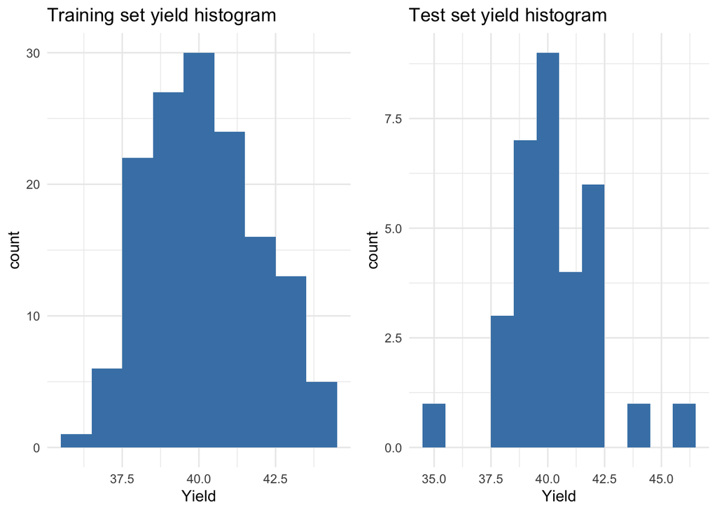

```r
library(gridExtra)
# Set seed
set.seed(777)

# Split into train/test; createDataPartition generates indicies of the training set
train_indices <- createDataPartition(dfchem$Yield, p=0.80, times=1, list=F)
dftrain <- dfchem[train_indices,]
dftest <- dfchem[-train_indices,]


# Examine train and test sets
plot1 <- ggplot(data = dftrain, aes(x=Yield)) + geom_histogram(fill = "steelblue", binwidth = 1) +
  ggtitle('Training set yield histogram')

plot2 <- ggplot(data = dftest, aes(x=Yield)) + geom_histogram(fill = "steelblue", binwidth = 1) +
  ggtitle('Test set yield histogram')

grid.arrange(plot1, plot2, ncol = 2)
```

Now we’ll examine the predictors to look for correlations and examine their relationship to the outcome variable.

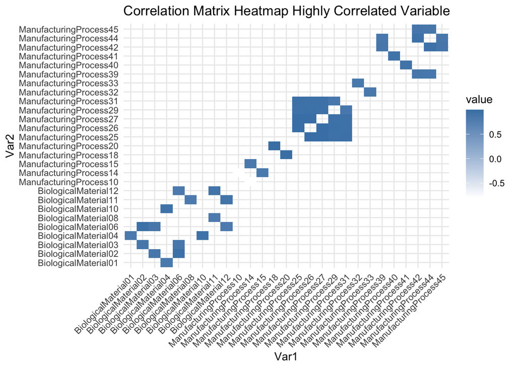

```r
# Calculate the correlation matrix
corr_matrix <- cor(dftrain)

# Set threshold
cutoff <- 0.8

# Reshape, find candidates for removal
filtered_corr_long <- reshape2::melt(corr_matrix) %>% dplyr::filter(abs(value) > cutoff & value !=1)
filtered_corr <- reshape2::dcast(filtered_corr_long, Var1 ~ Var2)


# Plot the correlation matrix heatmap
ggplot(data = filtered_corr_long, aes(x = Var1, y = Var2, fill = value)) +
  geom_tile() +
  scale_fill_gradient(low = "white", high = "steelblue") +
  labs(title = "Correlation Matrix Heatmap Highly Correlated Variable") +
  theme_minimal() +
  theme(axis.text.x = element_text(angle = 45, hjust = 1))
```

Because a large number of variables are highly correlated, a modeling technique which is robust to correlated variables is preferred, or else one feature of the highly correlated pair should be dropped. For this reason I will tune elastic net, which can handle multicollinearity.

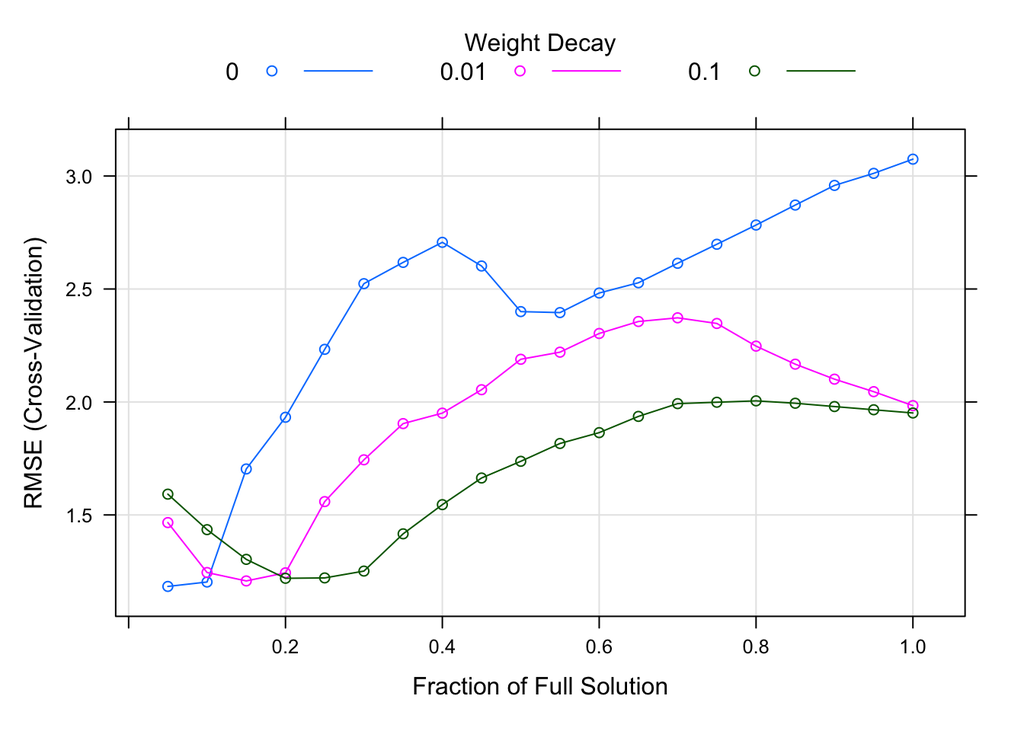

```r
# Results data frame
dfr <- data.frame(matrix(nrow=1, ncol=4))
colnames(dfr) <- c('Model', 'Tuning.Parameters', 'Train.RMSE', 'Test.RMSE')

# Separate outcome and predictors
trainx <- dftrain %>% dplyr::select(-Yield)
trainy <- dftrain$Yield
testx <- dftest %>% dplyr::select(-Yield)
testy <- dftest$Yield

# specify 10x cross-validation
ctrl <- caret::trainControl(method='cv', number=10) # caret package

# elastic net regression
enetGrid <- expand.grid(.lambda=c(0, 0.01, 0.1), .fraction=seq(0.05, 1, length=20))
enet_fit <- train(x=trainx, y=trainy, method='enet', preprocess=c('center', 'scale'), trControl=ctrl, tuneGrid=enetGrid)
enet_fit %>% plot()
```

### (d)

**Predict the response for the test set. What is the value of the performance metric and how does this compare with the resampled performance metric on the training set?**

First, calculate the accuracy based on the test set.

```r
# Generate y predictions
predy <- predict(enet_fit, newdata=testx)

# Get accuracy results
enet_acc <- accuracy(predy, testy)

dfr[1,] = data.frame(
    Model='Elastic net',
    Tuning.Parameters=
      paste0('lambda=', enet_fit$bestTune[['lambda']], ', fraction=', enet_fit$bestTune[['fraction']]),
    Train.RMSE=enet_fit$results[['RMSE']],
    Test.RMSE=enet_acc[[2]] %>% round(2) #RMSE for test set
)

dfr %>% kable(digits = 2)
```

| Model | Tuning.Parameters | Train.RMSE | Test.RMSE |
| --- | --- | --- | --- |
| Elastic net | lambda=0, fraction=0.05 | 1.18 | 1.34 |

The RMSE for the test set is very slightly higher than that of the training set (1.34 vs 1.1835187, respectively). This indicates good model fit and a lack of overfitting.

### (e)

**Which predictors are most important in the model you have trained? Do either the biological or process predictors dominate the list?**

It’s very challenging to understand the relative importance of predictors in a methodology that chooses predictors based n performance, especially when many features are highly correlated.

(See, for examplem (https://stats.stackexchange.com/questions/403303/how-to-interpret-metric-lasso-regression-coefficients)[https://stats.stackexchange.com/questions/403303/how-to-interpret-metric-lasso-regression-coefficients])

### (f)

**Explore the relationships between each of the top predictors and the response. How could this information be helpful in improving yield in future runs of the manufacturing process?**